# SENTIMENTAL ANALYSIS

# 1.INTRODUCTION

The main objective of this paper is to carry out a sentimental analysis of two books from the Project Gutenberg collection. Project Gutenberg is a library of over 60,000 custom e-books. It is a voluntary initiative to digitalize and collect cultural works and to promote the creation and distribution of e-books. It was founded in 1971 by American writer Michael S Hart and is the oldest digital library. Most of the contents of his collection are full-text books in the public sector. Sentiment analysis is an effective way to explore an author’s feelings towards a subject. This paper aims to analyze two books, one from the child playlist and the other from the adult playlist from the Gutenberg Collection, and compare the overall emotions and sentiments throughout these works using String processing and Text Mining. I am taking the books “Alice’s Adventures in Wonderland” by Lewis Carroll from child list and “GREAT EXPECTATIONS” by Charles Dickens from the adult list as my case studies. “Alice’s Adventures in Wonderland” is a story about a little girl Alice who falls down a rabbit hole and delves into a fantasy world filled with wonderful people and animals with full of surprises. This is a children’s classical book that is also appreciated by adults whereas “Great Expectations” tells us the story of an orphan boy who is adopted by a blacksmith’s family, who has good luck and great expectations, and then loses both his luck and his expectations. However, he learns to find happiness in this phase and breakdown. He learns the importance of friendship and love and, of course, thrives and becomes a better person for it.

# 2.Method

## 2.1 Prelimainary Data Analysis

```
## 'data.frame':    3380 obs. of  2 variables:
##  $ gutenberg_id: int  11 11 11 11 11 11 11 11 11 11 ...
##  $ text        : chr  "[Illustration]" "" "" "" ...
```

```
## 'data.frame':    20024 obs. of  2 variables:
##  $ gutenberg_id: int  1400 1400 1400 1400 1400 1400 1400 1400 1400 1400 ...
##  $ text        : chr  "GREAT EXPECTATIONS" "" "[1867 Edition]" "" ...
```

To start my data analysis I have assigned the dataset "“Alice’s Adventures in Wonderland” to a variable called “child” and the dataset “Great Expectations” to a variable called “adult”. When look at the structure of the data I found that the child dataset consist of 3380 rows and 2 columns and adult dataset consist 20024 rows and 2 columns.The names of the variables(coulmns) of both datasets(child and adult) is found to be “gutenberg_id” and “text”.

For the convinience of text mining converting the dataframes to tibbles.Benifits of tibbles compared to data frames are Tibbles have nice printing method that display only the first 10 rows and all the columns that fit on the screen. This is convenient when you work with large data sets. When printed, the data type of each column is specified.

## 2.2 Tidytext format

#### consider the text “Why these lazy people come to Co-operative jobs”

#### **word tokens :** Here splitting is based on words(or white space)

#### “why”

#### “these”

#### “lazy”

#### “people”

#### “come”

#### “Co-operative”

#### “jobs”

#### **subword tokens :** consider the word “Co-operative”, here it splits based on subword

#### “co”

#### “operative”

#### **Character tokens :** consider the word “No”, the splitting is based on each chacter of the word.

#### “N”

#### “o”

```
## # A tibble: 213,359 x 5
##    gutenberg_id Book                            Author       Chapter word
##           <int> <chr>                           <chr>          <int> <chr>
##  1           11 Alice’s Adventures in Wonderla~ Lewis Carro~       0 illustrati~
##  2           11 Alice’s Adventures in Wonderla~ Lewis Carro~       0 alice’s
##  3           11 Alice’s Adventures in Wonderla~ Lewis Carro~       0 adventures
##  4           11 Alice’s Adventures in Wonderla~ Lewis Carro~       0 in
##  5           11 Alice’s Adventures in Wonderla~ Lewis Carro~       0 wonderland
##  6           11 Alice’s Adventures in Wonderla~ Lewis Carro~       0 by
##  7           11 Alice’s Adventures in Wonderla~ Lewis Carro~       0 lewis
##  8           11 Alice’s Adventures in Wonderla~ Lewis Carro~       0 carroll
##  9           11 Alice’s Adventures in Wonderla~ Lewis Carro~       0 the
## 10           11 Alice’s Adventures in Wonderla~ Lewis Carro~       0 millennium
## # ... with 213,349 more rows
```

### 2.2.1 Removing stop words

The next step is removing the stop words in the text. When analyse at the context of the text it can be seen that the dataset contains so many stop words such as “the”, “as”, “and”,“of”,“to” etc. these words are useless for our sentimental analysys so we can remove these words using tidytext anti_join() function.

### 2.2.2 Counting the most common words

In order to count the most common words in the books we can use dplyr’s count() function

```
## # A tibble: 11,058 x 2
##    word        n
##    <chr>   <int>
##  1 joe       691
##  2 time      444
##  3 miss      387
##  4 alice     386
##  5 looked    370
##  6 pip       326
##  7 hand      291
##  8 herbert   290
##  9 head      281
## 10 wemmick   256
## # ... with 11,048 more rows
```

## 2.3 The sentiment dataset

There are a diversity of methods and dictionaries that are available for assessing the view or emotion in text. The tidytext package offers access to numerous sentiment lexicons. Three general-purpose lexicons are as follows

#### **a)AFINN from Finn Årup Nielsen:**The AFINN lexicon allocates words with a score that turns between -5 and 5, with negative scores representing negative sentiment and positive scores representing positive sentiment.

#### **b)bing from Bing Liu and collaborators:**This lexicon classifies words in a binary fashion into positive and negative categories.

#### **c)nrc from Saif Mohammad and Peter Turney:**This lexicon classifies words in a binary manner (“yes”/“no”) into categories of positive, negative, anger, anticipation, disgust, fear, joy, sadness, surprise, and trust.

```
## # A tibble: 6,786 x 2
##    word        sentiment
##    <chr>       <chr>
##  1 2-faces     negative
##  2 abnormal    negative
##  3 abolish     negative
##  4 abominable  negative
##  5 abominably  negative
##  6 abominate   negative
##  7 abomination negative
##  8 abort       negative
##  9 aborted     negative
## 10 aborts      negative
## # ... with 6,776 more rows
```

All of these three lexicons are grounded on unigrams (single words). These lexicons comprise numerous English words that describes emotions like joy, anger, sadness, and so on, and each word has a specific score based on positive or negative sentiment.

Now lets use the nrc sentiment dataset to measure the different sentiments that are embodied across the books.

```
## # A tibble: 10 x 2
##    sentiment        n
##    <chr>        <int>
##  1 positive      8974
##  2 negative      8300
##  3 trust         5270
##  4 fear          4183
##  5 anticipation  4005
##  6 sadness       3759
##  7 joy           3285
##  8 anger         3278
##  9 disgust       2701
## 10 surprise      1893
```

The above table gives an overall idea about the sentiments throughout the 2 books.Now our aim is to analyse the sentiments seperately among each chapter of each book as the story progressess.In order to achieve this creating an index that splits each books by 600 words, this is an approximate count of words on every two pages so this will allow us to evaluate deviations in sentiments even within chapters. Then inputting “bing” lexicon to inner_join() function to access the positive vs. negative sentiment of each word. Then counting the positive and negative words in every two pages. We then use spread() so that we get negative and positive sentiment in separate columns, and finally calculate a net sentiment (positive - negative) and plotting with the help of ggplot.

# Results

## 3.1 Comparing the two books

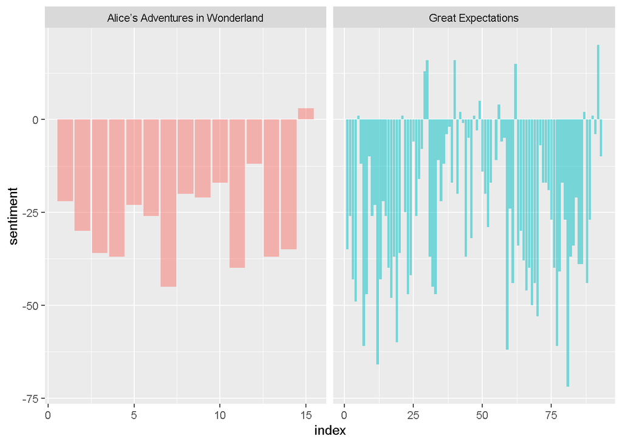

The plot shows how each book vagaries towards more positive or negative sentiment over the trajectory of the story.

## 3.2 Comparing Sentiments

Through numerous options for sentiment lexicons, we might need some more information on which one is proper for our purposes. Let’s analyse all three sentiment lexicons and observe how the sentiment changes across the books.AFINN lexicon estimates sentiment with a numeric score between -5 and 5, while the other two lexicons classifies words in a binary fashion, either positive or negative. So we need to create a seperate pattern for AFINN and one or bing and nrc.

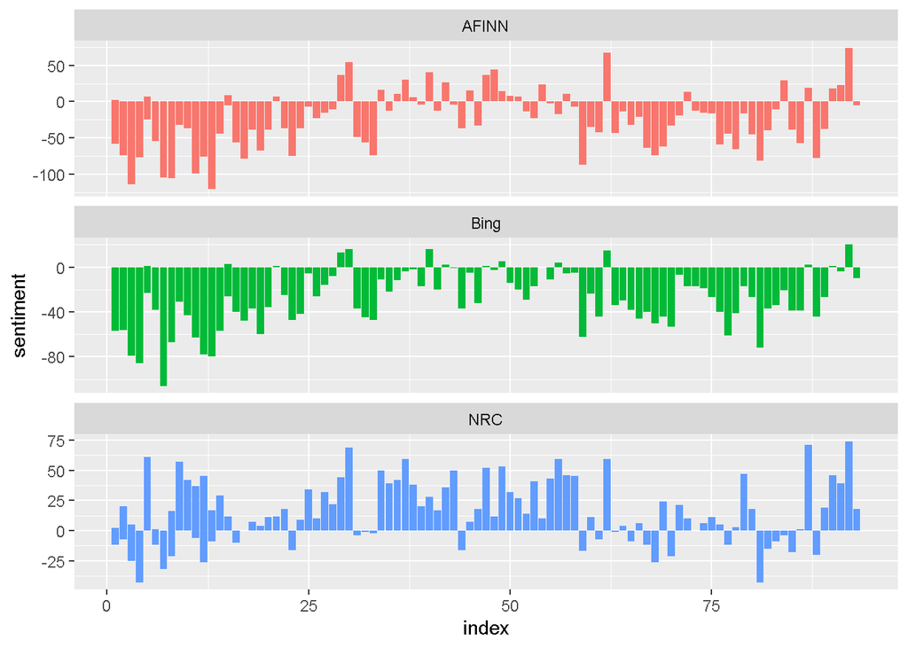

The three different lexicons for conniving sentiment bounce results that are diverse in an absolute sense but have similar relative trajectories through the books.It has been noted that the afinn and bing lexigons are shifted to gives the largest absolute values, with high negative values throughout the books.The NRC results are shifted higher relative to the other two, labeling the text more positively, but detects similar relative changes in the text. Now lets look into the variations of these lexigons seperately in each book.

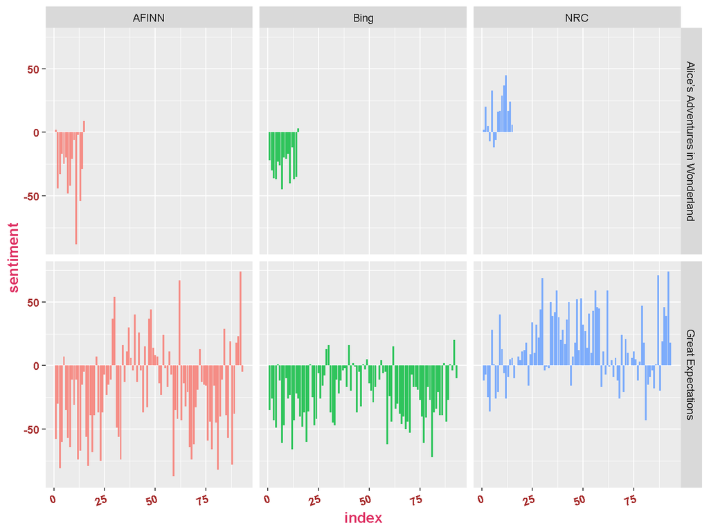

From this it is clear that the lexicons afinn and bing shows a negative shift throughout the book “Alice’s Adventures in Wonderland” whereas the nrc lexigons shifted more positive. But for “Great Expectations” there is a huge difference in shifts for all the 3 lexigons.The ratio of positive to negative words in afinn is high compared to other two and is shifted more to negative.Bing also shifted more to negative whereas the nrc lexicon is shifted to more positive.

```
## # A tibble: 2,017 x 3
##    word   sentiment     n
##    <chr>  <chr>     <int>
##  1 miss   negative    387
##  2 poor   negative    104
##  3 dark   negative     74
##  4 hard   negative     67
##  5 doubt  negative     64
##  6 love   positive     62
##  7 fell   negative     61
##  8 glad   positive     57
##  9 mock   negative     57
## 10 strong positive     56
## # ... with 2,007 more rows
```

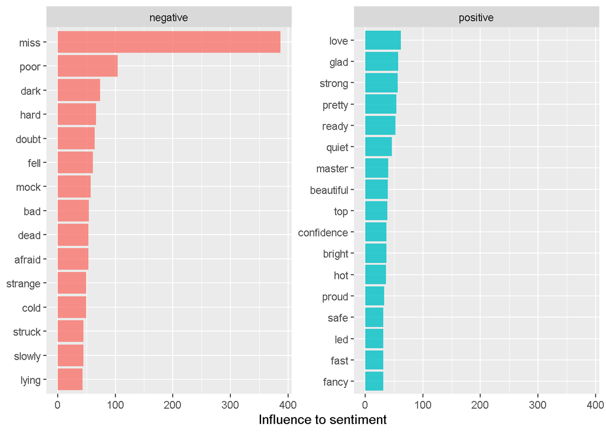

Bing lexicon treats the word “miss” more negatively and is appearing more throughot the books.

## Wordcloud of the book “Alice’s Adventures in Wonderland”

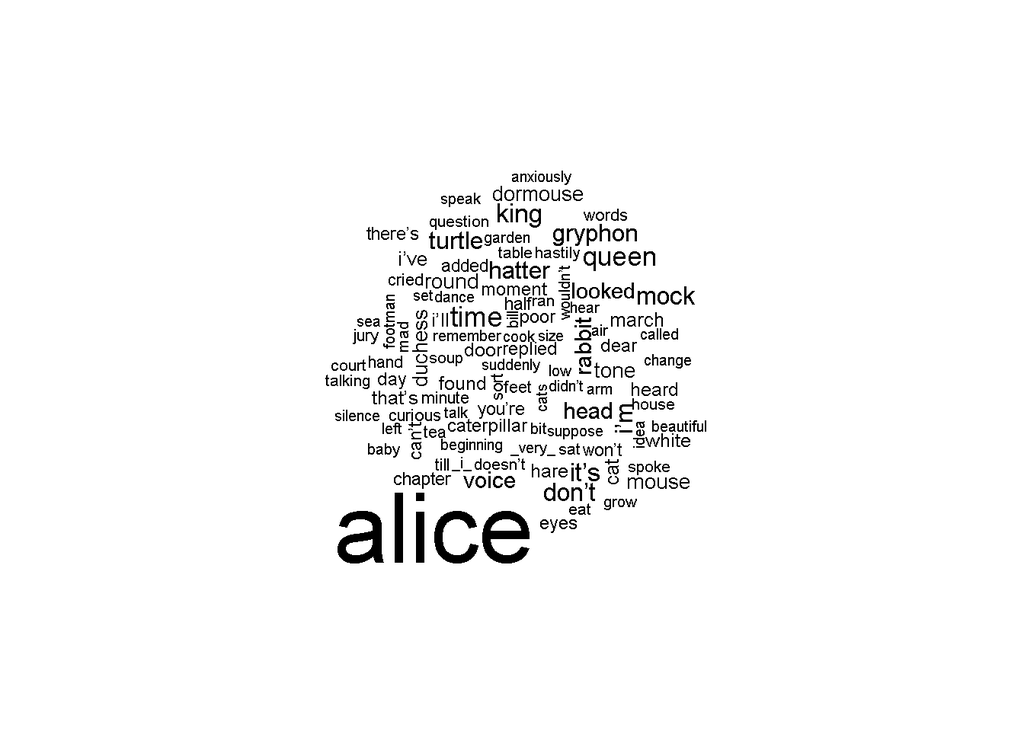

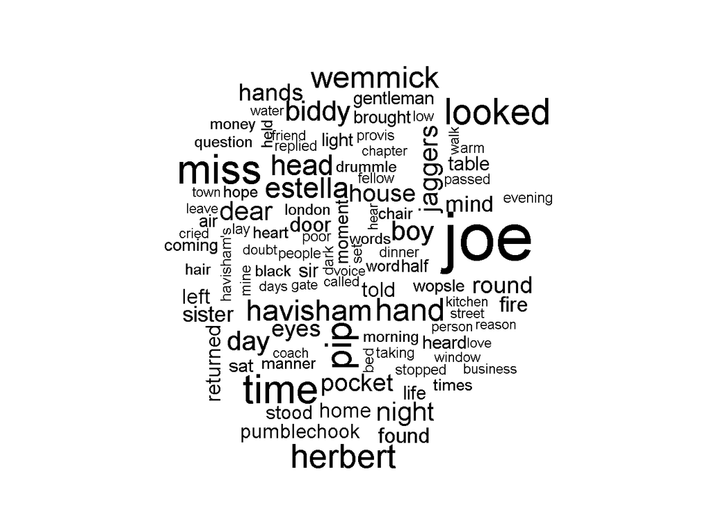

### Overall positive and negative words within 2 books

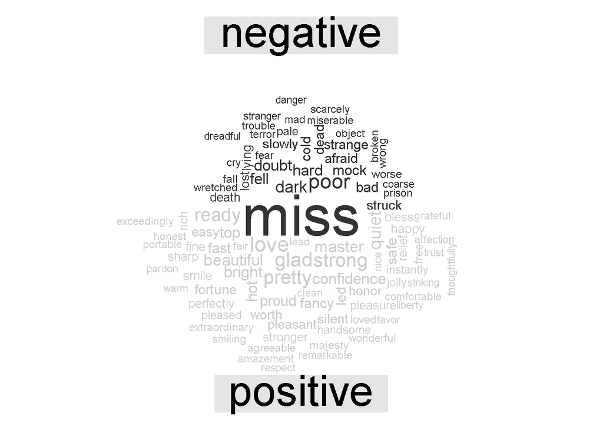

Lets create 2 two tables in which one contain the list of negative words andthe other contain list positive words from the Bing lexicon which are present in each book and calculate percentage of negative/positive words per each chapter. The table only shows the top one chapter in each book contain more percentage of positive or negative words.

```
## # A tibble: 2 x 5
##   Book                             Chapter Negative_words words percentage
##   <fct>                              <int>          <int> <int>      <dbl>
## 1 Alice’s Adventures in Wonderland       6             85   789       10.8
## 2 Great Expectations                    44            116   777       14.9
```

```
## # A tibble: 2 x 5
##   Book                             Chapter Positive_words words percentage
##   <fct>                              <int>          <int> <int>      <dbl>
## 1 Alice’s Adventures in Wonderland       1             32   616       5.19
## 2 Great Expectations                    17             86   885       9.72
```

# Discussion

Sentiment analysis offers a method to realize the attitudes and feelings spoken in texts. we explored how to tactic sentiment analysis by means of tidy data principles. We can effectively convey an Author’s emotions in text using lexicons but the main challenge is different lexicons shows some kind of variations for the same text. For example if some words are treated as negative in one lexicon the same word may be treated as positive by other lexicons. But overall it shows same shifts throughout the trajectory of the book.